# Practical Machine Learning

Thiago Almeida

18 de julho de 2018

```r
knitr::opts_chunk$set(echo = TRUE, cache = TRUE, cache.lazy = FALSE)
library(caret)
library(rattle)
```

## Introduction

Using devices such as Jawbone Up, Nike FuelBand, and Fitbit it is now possible to collect a large amount of data about personal activity relatively inexpensively. These type of devices are part of the quantified self movement - a group of enthusiasts who take measurements about themselves regularly to improve their health, to find patterns in their behavior, or because they are tech geeks. One thing that people regularly do is quantify how much of a particular activity they do, but they rarely quantify how well they do it. In this project, your goal will be to use data from accelerometers on the belt, forearm, arm, and dumbell of 6 participants. They were asked to perform barbell lifts correctly and incorrectly in 5 different ways. More information is available from the website here: http://web.archive.org/web/20161224072740/http:/groupware.les.inf.puc-rio.br/har (see the section on the Weight Lifting Exercise Dataset).

## Loading Data

Loading data from web.

```r
#load train
urltrain <- read.csv(url("https://d396qusza40orc.cloudfront.net/predmachlearn/pml-training.csv"),header=TRUE,na.strings = c("", "NA"))
urltest <- read.csv(url("https://d396qusza40orc.cloudfront.net/predmachlearn/pml-testing.csv"),header=TRUE,na.strings = c("", "NA"))
```

## Visualize Data

```r
#visualize data
str(urltrain)
```

```
## 'data.frame':    19622 obs. of  160 variables:
##  $ X                       : int  1 2 3 4 5 6 7 8 9 10 ...
##  $ user_name               : Factor w/ 6 levels "adelmo","carlitos",..: 2 2 2 2 2 2 2 2 2 2 ...
##  $ raw_timestamp_part_1    : int  1323084231 1323084231 1323084231 1323084232 1323084232 1323084232 1323084232 1323084232 1323084232 1323084232 ...
##  $ raw_timestamp_part_2    : int  788290 808298 820366 120339 196328 304277 368296 440390 484323 484434 ...
##  $ cvtd_timestamp          : Factor w/ 20 levels "02/12/2011 13:32",..: 9 9 9 9 9 9 9 9 9 9 ...
##  $ new_window              : Factor w/ 2 levels "no","yes": 1 1 1 1 1 1 1 1 1 1 ...
##  $ num_window              : int  11 11 11 12 12 12 12 12 12 12 ...
##  $ roll_belt               : num  1.41 1.41 1.42 1.48 1.48 1.45 1.42 1.42 1.43 1.45 ...
##  $ pitch_belt              : num  8.07 8.07 8.07 8.05 8.07 8.06 8.09 8.13 8.16 8.17 ...
##  $ yaw_belt                : num  -94.4 -94.4 -94.4 -94.4 -94.4 -94.4 -94.4 -94.4 -94.4 -94.4 ...
##  $ total_accel_belt        : int  3 3 3 3 3 3 3 3 3 3 ...
##  $ kurtosis_roll_belt      : Factor w/ 396 levels "-0.016850","-0.021024",..: NA NA NA NA NA NA NA NA NA NA ...
##  $ kurtosis_picth_belt     : Factor w/ 316 levels "-0.021887","-0.060755",..: NA NA NA NA NA NA NA NA NA NA ...
##  $ kurtosis_yaw_belt       : Factor w/ 1 level "#DIV/0!": NA NA NA NA NA NA NA NA NA NA ...
```

[output cut: 86 more lines]

## Cleaning Data

In this dataset there are to many NA values. In this step the NA columns will be excluded. The same columns will be excluded in test data.

```r
#exclude NA columns
train <- urltrain[, colSums(is.na(urltrain)) == 0]
test <- urltest[, colSums(is.na(urltrain)) == 0]
```

There are correlated columns that can be excluded.

```r
#exclude columns with high correlation
cor.matrix <- cor(train[sapply(train, is.numeric)])
c <- findCorrelation(cor.matrix, cutoff = .90)
train <- train[,-c]
```

## Spliting Validation Dataset

The train dataset will be splitted for validation.

```r
#seed
set.seed(9876)

#split 75%
inTrain <- createDataPartition(train$classe, p=0.75, list=FALSE)
train <- train[inTrain,]
valid <- train[-inTrain,]
```

## Decision Tree

The first method will be Decision Tree using the Caret library

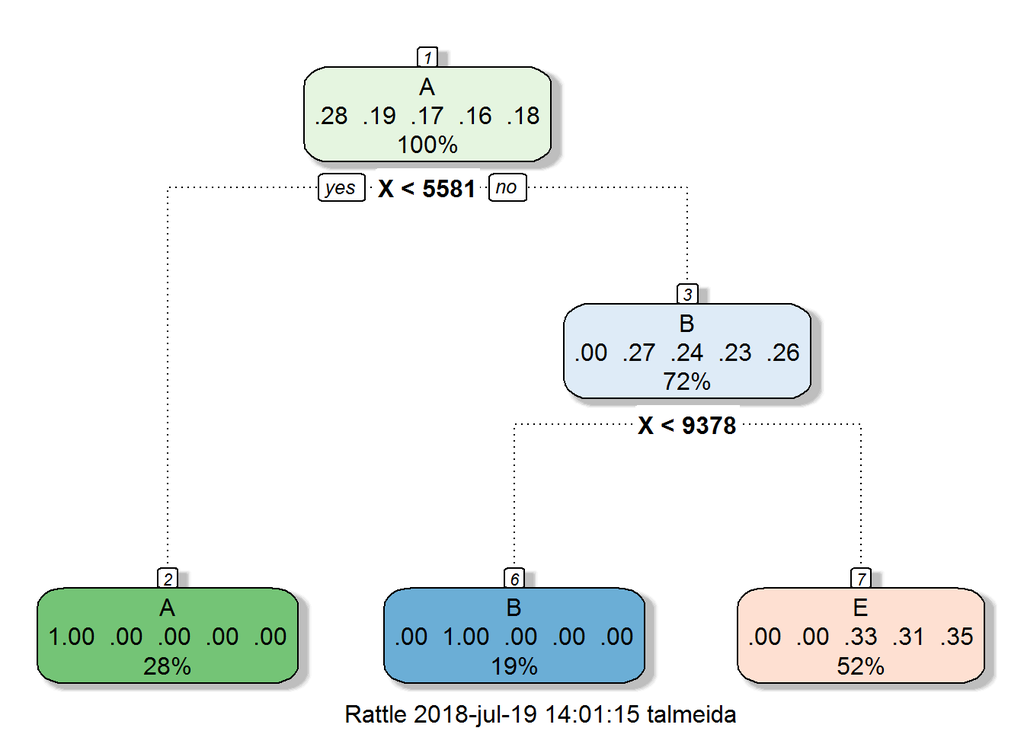

```r
#control
control <- trainControl(method="cv", number=3, classProbs=TRUE, allowParallel=TRUE, verboseIter = FALSE)

#model
fit_rpart <- train(classe ~ ., data = train, method = "rpart", trControl = control)

#plot
fancyRpartPlot(fit_rpart$finalModel)
```

```r
#predict
pred_rpart <- predict(fit_rpart, valid)

confusion_rpart <- confusionMatrix(valid$classe, pred_rpart)
```

The accuracy of this method is 0.659875

## Randon Forest

The second method will be Randon Forest using the Caret library

```r
#model
fit_rf <- train(classe ~ ., data = train, method = "rf", trControl = control, ntree=500, keep.forest=TRUE, importance=TRUE)

#predict
pred_rf <- predict(fit_rf, valid)

confusion_rf <- confusionMatrix(valid$classe, pred_rf)
```

The accuracy of this method is 1

## Gradient Boosting Method

The second method will be Gradient Boosting Method using the Caret library

```r
#model
fit_gbm <- train(classe ~ ., data = train, method = "gbm", trControl = control)
```

```r
#predict
pred_gbm <- predict(fit_gbm, valid)

confusion_gbm <- confusionMatrix(valid$classe, pred_gbm)
```

The accuracy of this method is 1

## Using Test Data

```r
#predict
pred_test <- predict(fit_rf, test)
```